# Palestras convidadas

Nesta oitava edição, contaremos com a presença de palestrantes proeminentes no campo da programação com R, com experiência tanto na academia quanto na indústria, comprometidos com a colaboração e a promoção da ciência, dados e software abertos.

## Palestrantes

Heather Turner

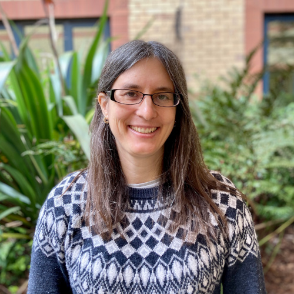

Heather Turner é pesquisadora em Engenharia de Software Científico e professora associada de Estatística na Universidade de Warwick, Reino Unido. Ela participa ativamente da comunidade R; em particular, faz parte da diretoria da Fundação R (R Foundation) e preside tanto o Grupo de Trabalho de Contribuição do R (R Contribution Working Group) quanto a iniciativa Forwards para grupos sub-representados.

Stephanie Zimmer

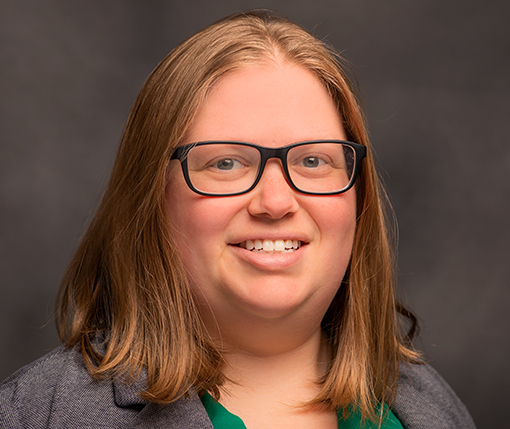

Stephanie Zimmer é uma estatística sênior na RTI com uma década de experiência em amostragem e desenho de pesquisas, ponderação e análise de dados, e gestão de dados. Ela é especialista em programação estatística, instrutora certificada, e coautora do livro Exploring Complex Survey Data Analysis Using R.

Equipo TRACE-LAC

[figure not shown]

TRACE-LAC é um projeto financiado pelo International Development Research Centre, liderado pela Pontifícia Universidade Javeriana e a Universidade dos Andes. Busca informar sobre a tomada de decisões na resposta a epidemias por doenças infecciosas na América Latina e Caribe. TRACE-LAC está articulado com as iniciativas TRACE e Epiverse lideradas pela London School of Hygiene and Tropical Medicine em colaboração com o Medical Research Council Unit na Gâmbia.

## Palestras

### Heather Turner: Lowering Barriers to Contributing to R

It is 30 years since R was released under an open source license and today R is used by millions of people worldwide. Ensuring that R remains a solid foundation for people’s work requires ongoing development and maintenance. The general R community can play an important part in sustaining R for the future. In this keynote, I’ll share some recent initiatives that lower barriers to contribution. We’ll explore two tools that simplify the process of contributing:

Weblate for contributing translations of errors, warnings and messages, and the R Dev Container for contributing to the code and documentation. These tools require minimal setup, so you can focus on the interesting work! We’ll discover how these tools have been used by participants at collaborative events - translation hackathons and R Dev Days - organised by the R Contribution Working Group in recent years. Finally, I’ll discuss how you can find tasks, get support, and start contributing, so that together we can ensure R continues to thrive for decades to come.

### Stephanie Zimmer: Transforming a team to open-source first

Three years ago, a small group at my work formed an open-source software committee in a land where statisticians primarily used a commercially available software. We wanted to champion an open-source first initiative and convert people and projects to using open-source software. I will talk about what we did to make this happen and how the process accelerated. Some of the key things I was involved in were open-source office hours which formed a great community, developing an R package when we couldn’t find something we needed in R, and developing small examples of common things we do in our work in R with a comparison to the prior method.

### Equipo TRACE_LAC: Lo invisible del código abierto: Lecciones desde el proyecto TRACE-LAC / Epiverso para conectar el desarrollo de software con la salud pública

O Epiverso é uma iniciativa colaborativa global liderada pela data.org, que tem como objetivo desenvolver um ecossistema confiável de análise de dados dedicado a se antecipar à próxima crise de saúde pública. Por meio do desenvolvimento de ferramentas analíticas de alta qualidade, de código aberto e transparentes, e da criação de uma comunidade de usuários.